# Introduction to R programming for data science – day 5

## Re-plot the cars dataset

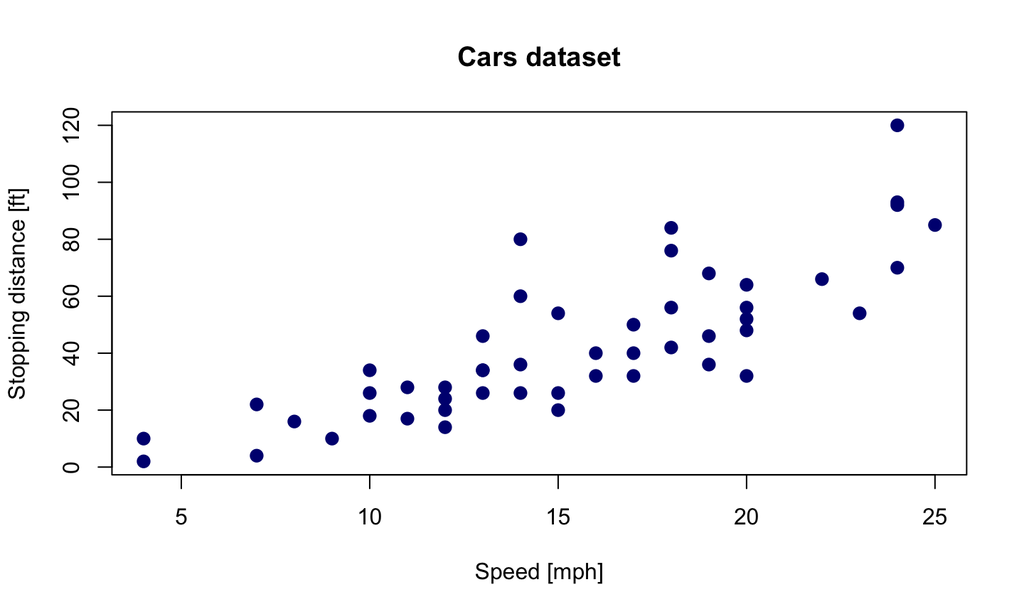

```r
plot(cars[,"speed"], cars[,"dist"],
  xlab="Speed [mph]", ylab="Stopping distance [ft]",
  main="Cars dataset", pch=19, col="navyblue", cex=1.2)
```

## The *points* function

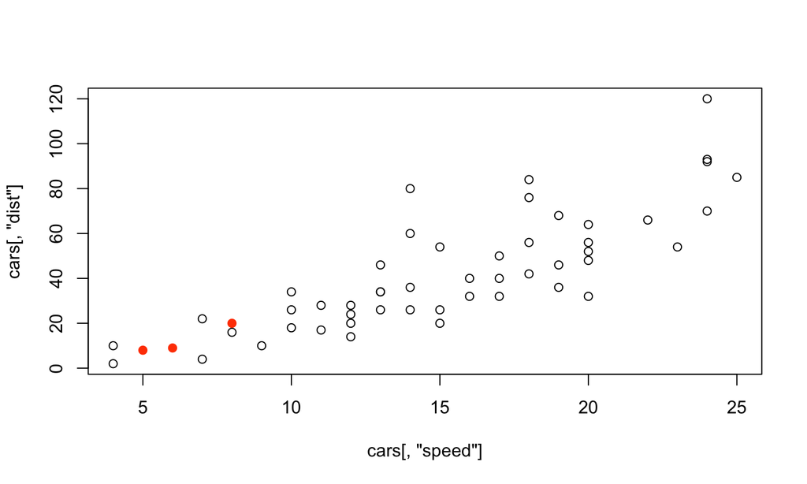

```r
plot(cars[,"speed"], cars[,"dist"])
x <- c(5, 6, 8); y <- c(8, 9, 20)
points(x, y, col="orangered", pch=19) # Add points to a previous plot
```

## The *lines* function

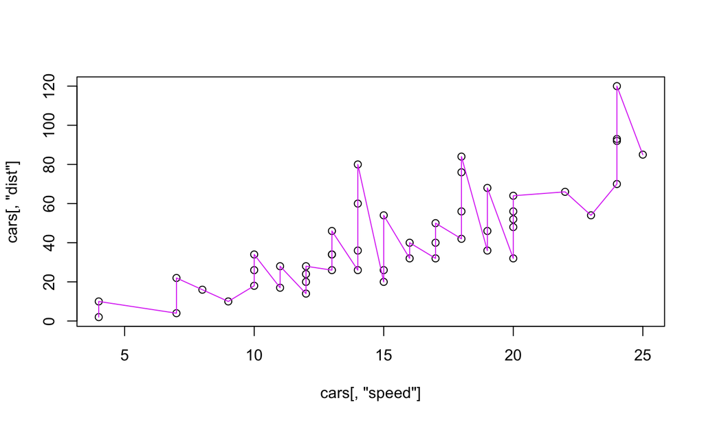

```r
plot(cars[,"speed"], cars[,"dist"])
lines(x=cars[,"speed"], y=cars[,"dist"],
  col="#dc42f4") # Add lines to a previous plot
```

## The *abline* function

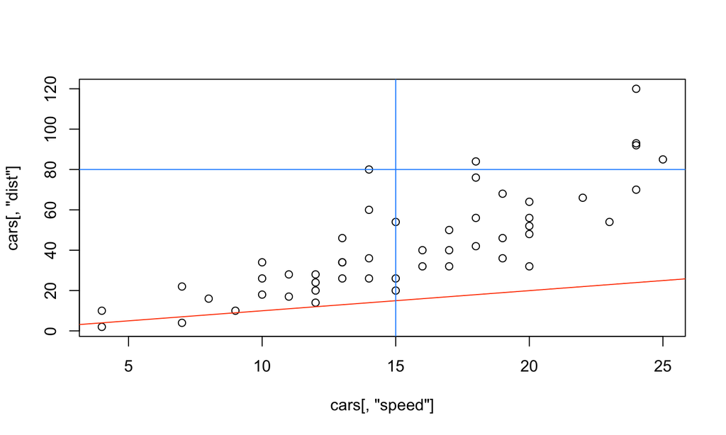

```r
plot(cars[,"speed"], cars[,"dist"])
abline(a=0, b=1, col="orangered") # Intercept and slope (here x=y)
abline(v=15, col="dodgerblue") # Vertical line
abline(h=80, col="dodgerblue") # Horizontal line
```

## Adding a linear fit

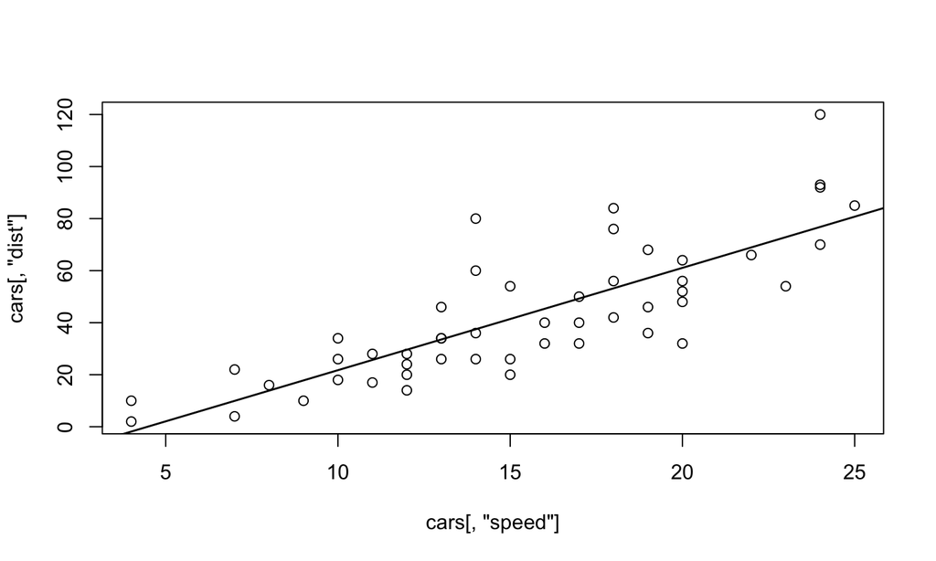

```r
plot(cars[,"speed"], cars[,"dist"])
lfit <- lm(dist~speed, data=cars) # Linear fit of dist (y) on speed (x)
abline(lfit, col=1, lwd=1.5)
```

## The *text* function

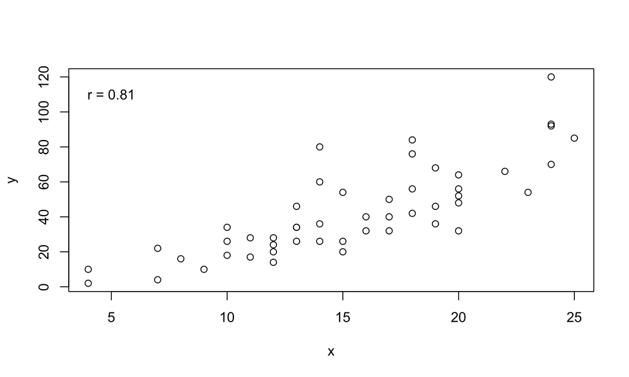

```r
x <- cars[,"speed"]; y <- cars[,"dist"]; plot(x,y)
r <- round(cor(x,y), 2)
text(x=5, y=110, labels=paste("r =", r))
```

## The *barplot* function

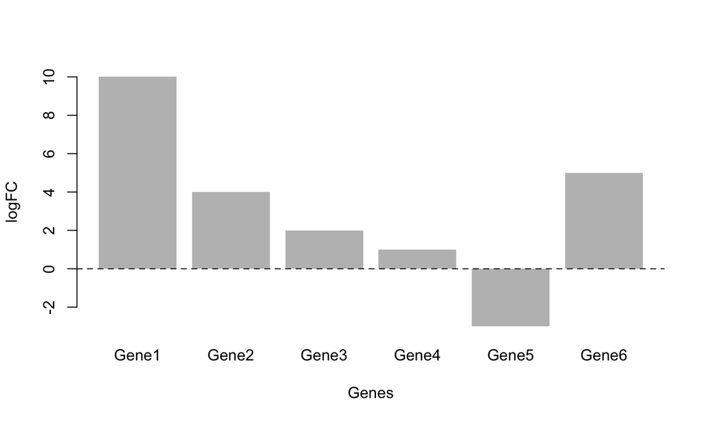

```r
x <- c(10, 4, 2, 1, -3, 5)
names(x) <- c("Gene1", "Gene2", "Gene3", "Gene4", "Gene5", "Gene6")
barplot(x, xlab="Genes", ylab="logFC", border=NA)
abline(h=0, lty=2, col="grey4")
```

## The *hist* and *density* functions

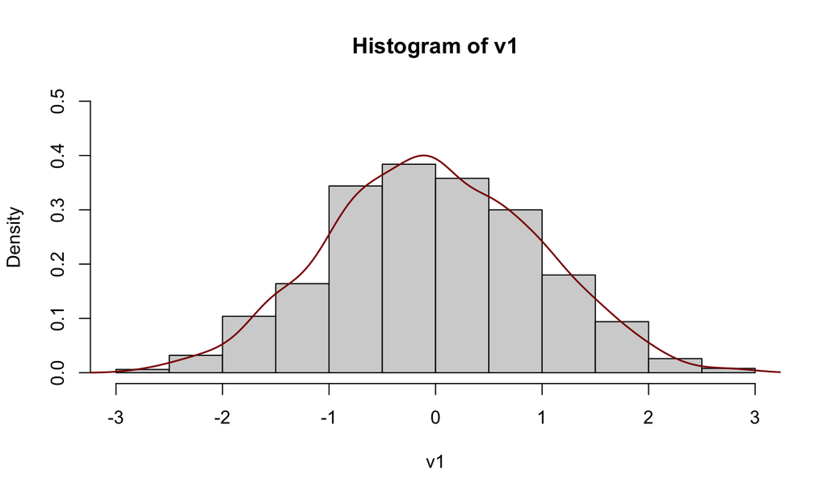

```r
v1 <- rnorm(1000, mean=0, sd=1)
hist(v1, freq=FALSE, ylim=c(0,0.5))         # TRUE for frequencies, FALSE for densities
lines(density(v1), col="darkred", lwd=1.5)  # "density" does not plot
```

## The *boxplot* function

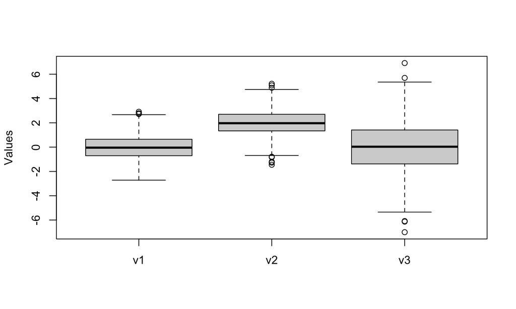

```r
v2 <- rnorm(1000, mean=2, sd=1)
v3 <- rnorm(1000, mean=0, sd=2)
boxplot(list(v1=v1, v2=v2, v3=v3), ylab="Values")
```

## Boxplots

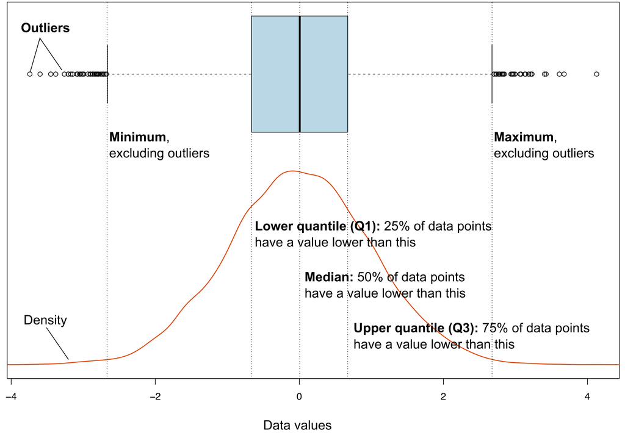

## Save plots in a file

Functions like pdf and png can be used to save R plots into images and take as main input the figure name and path (see help for additional parameters)

```r
pdf("Figures/boxplot.pdf")
boxplot(list(v1=v1, v2=v2, v3=v3), ylab="Values")
dev.off()
```

```r
png("Figures/boxplot.png")
boxplot(list(v1=v1, v2=v2, v3=v3), ylab="Values")
dev.off()
```

dev.off must be used to close the device after plotting

dev.list can be used to know which devices are open

## The *tidiverse* package collection

[figure not shown]

[tidyverse](https://www.tidyverse.org/) is a collection of R packages designed for data science sharing common design philosophy, grammar, and data structures

You can install the complete **tidyverse** collection

```r
install.packages("tidyverse")
```

Or only single packages, like [ggplot2](https://ggplot2.tidyverse.org/)

```r
install.packages("ggplot2")
```

## The *ggplot2* package (1)

[figure not shown]

[ggplot2](https://ggplot2.tidyverse.org/) is a system for creating graphics, based on The Grammar of Graphics.

You specify:

- The data
- How to map variables to aesthetics
- Which graphical primitives to use

**ggplot2** takes care of the details

## The *ggplot2* package (2)

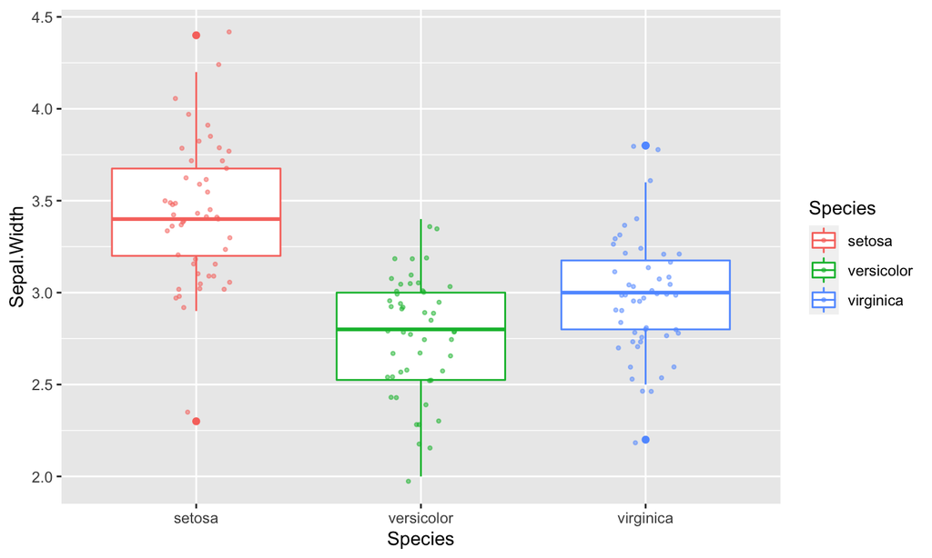

```r
ggplot(iris, mapping = aes(x = Species, y = Sepal.Width, color = Species)) +
  geom_boxplot() +
  geom_jitter(width = 0.15, height = 0.05, alpha = 0.5, size = 0.75)
```

## The *ggplot2* package (3)

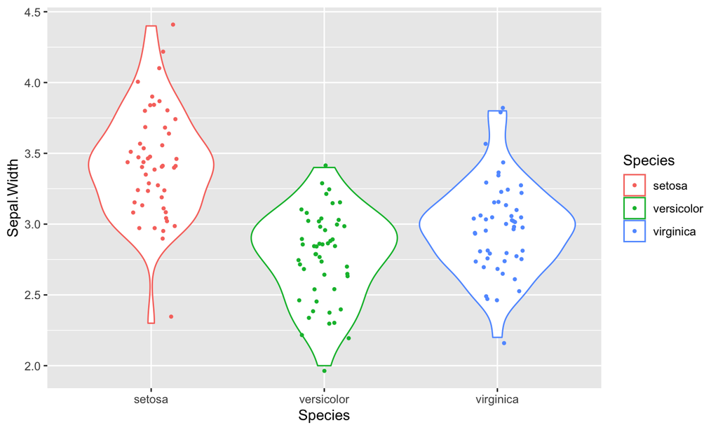

```r
ggplot(iris, mapping = aes(x = Species, y = Sepal.Width, color = Species)) +
  geom_violin() +
  geom_jitter(width = 0.15, height = 0.05, size = 0.8)
```